# **Obesity risk**

### **Within the higher weight range of 90-165 kg**:

##### Both females and males exhibit a bimodal weight distribution, suggesting subgroups within each gender at different weight points.

##### Females in this range tend to have their primary weight cluster slightly lower than males.

##### Males show a secondary cluster at a lower weight within this selection compared to the secondary cluster for females.

##### **Gender** with **Age > 30** and **Weight >= 90** and **Means of transportation used = Public_Transportation** or **Automobile**

```python
GenderGt30AndWeightGte90AndMeansTrans1 = train_df.loc[(train_df['Age'] > 30) & (train_df['Weight'] >= 90) &
             ((train_df['Means of transportation used'] == 'Public_Transportation') | (train_df['Means of transportation used'] == 'Automobile')) ,
             (['Age','Gender','Weight','Means of transportation used'])]
```

```python
GenderGt30AndWeightGte90AndMeansTrans1
```

|  | Age | Gender | Weight | Means of transportation used |
| --- | --- | --- | --- | --- |
| 4 | 32 | Male | 93.798055 | Public_Transportation |
| 46 | 31 | Male | 120.998266 | Public_Transportation |
| 102 | 31 | Male | 122.813033 | Public_Transportation |
| 103 | 32 | Male | 90.000000 | Automobile |
| 203 | 35 | Female | 90.000000 | Automobile |
| ... | ... | ... | ... | ... |
| 20583 | 34 | Male | 91.059595 | Automobile |
| 20598 | 31 | Male | 112.277567 | Automobile |
| 20635 | 31 | Male | 120.919703 | Automobile |
| 20710 | 34 | Male | 102.134646 | Automobile |
| 20747 | 33 | Male | 99.000000 | Automobile |

955 rows × 4 columns

```python
GenderGt30AndWeightGte90AndMeansTrans1['Gender'].value_counts()
```

```
Gender
Male      949
Female      6
Name: count, dtype: int64
```

```python
GenderGt30AndWeightGte90AndMeansTrans1['Means of transportation used'].value_counts()
```

```
Means of transportation used
Automobile               562
Public_Transportation    393
Name: count, dtype: int64
```

##### **Gender** with **Age > 30** and **Weight >= 90** and **Means of transportation used = Walking** or **Bike** or **Motorbike**

```python
GenderGt30AndWeightGte90AndMeansTrans2 = train_df.loc[(train_df['Age'] > 30) & (train_df['Weight'] >= 90) &
             ((train_df['Means of transportation used'] == 'Walking') | (train_df['Means of transportation used'] == 'Bike') | (train_df['Means of transportation used'] == 'Motorbike')) ,
             (['Age','Gender','Weight','Means of transportation used'])]
```

```python
GenderGt30AndWeightGte90AndMeansTrans2
```

|  | Age | Gender | Weight | Means of transportation used |
| --- | --- | --- | --- | --- |
| 3533 | 33 | Male | 91.0 | Walking |
| 4429 | 33 | Male | 97.0 | Walking |
| 17672 | 33 | Male | 91.0 | Walking |
| 17867 | 33 | Male | 113.0 | Walking |
| 18248 | 33 | Male | 97.0 | Walking |
| 18835 | 33 | Male | 103.0 | Walking |

##### **Gender** with **Age <= 30** and **Weight >= 90** and **Means of transportation used = Public_Transportation** or **Automobile**

```python
GenderLte30AndWeightGtet90AndMeansTrans1 = train_df.loc[(train_df['Age'] <= 30) & (train_df['Weight'] >= 90) &
             ((train_df['Means of transportation used'] == 'Public_Transportation') | (train_df['Means of transportation used'] == 'Automobile')) ,
             (['Age','Gender','Weight','Means of transportation used'])]
```

```python
GenderLte30AndWeightGtet90AndMeansTrans1
```

|  | Age | Gender | Weight | Means of transportation used |
| --- | --- | --- | --- | --- |
| 3 | 21 | Female | 131.274851 | Public_Transportation |
| 6 | 30 | Male | 112.725005 | Automobile |
| 7 | 30 | Male | 118.206565 | Automobile |
| 9 | 26 | Female | 111.275646 | Public_Transportation |
| 12 | 18 | Male | 108.251044 | Public_Transportation |
| ... | ... | ... | ... | ... |
| 20749 | 26 | Female | 104.835346 | Public_Transportation |
| 20751 | 21 | Female | 133.466763 | Public_Transportation |
| 20753 | 25 | Male | 114.187096 | Public_Transportation |
| 20755 | 20 | Male | 105.580491 | Public_Transportation |
| 20757 | 27 | Male | 118.134898 | Public_Transportation |

7943 rows × 4 columns

```python
GenderLte30AndWeightGtet90AndMeansTrans1['Gender'].value_counts()
```

```
Gender
Female    4151
Male      3792
Name: count, dtype: int64
```

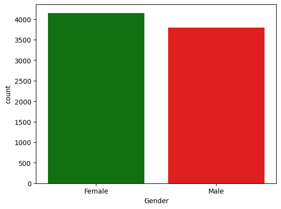

```python
countplot(x='Gender', data=GenderLte30AndWeightGtet90AndMeansTrans1, palette=['green','red'])
xlabel('Gender')
show()
```

```python
GenderLte30AndWeightGtet90AndMeansTrans1['Means of transportation used'].value_counts()
```

```
Means of transportation used
Public_Transportation    7449
Automobile                494
Name: count, dtype: int64
```

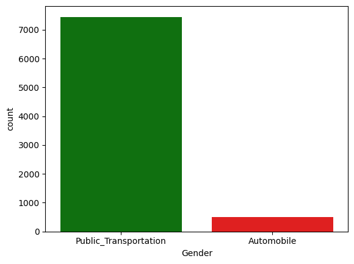

```python
countplot(x='Means of transportation used', data=GenderLte30AndWeightGtet90AndMeansTrans1, palette=['green','red'])
xlabel('Gender')
show()
```

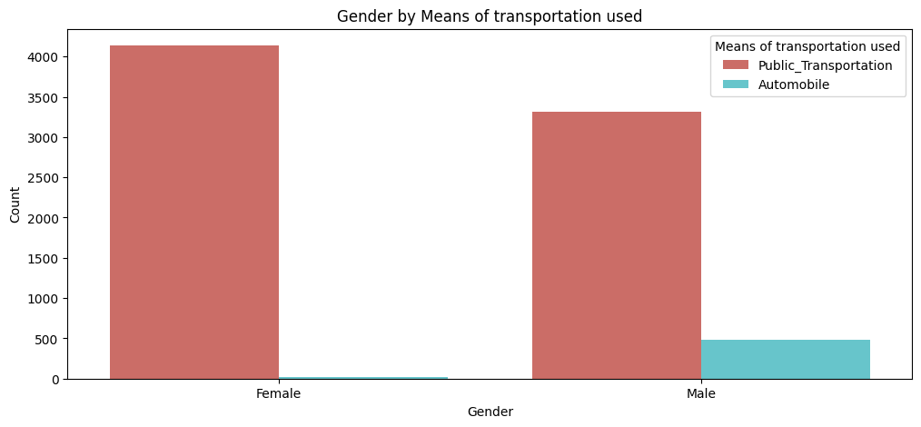

```python
figure(figsize=(12,	5))
countplot(data=GenderLte30AndWeightGtet90AndMeansTrans1, x='Gender', hue='Means of transportation used', palette="hls")
title('Gender by Means of transportation used')
xlabel('Gender')
ylabel('Count')
show()
```

### **For Females**:

##### **Public Transportation**: The vast majority of females in dataset report using public transportation. The count is significantly high, around 4150.

##### **Automobile**: A very small number of females report using automobiles as their means of transportation. The count is extremely low, close to zero.

### **For Males**:

##### **Public Transportation**: A substantial number of males also report using public transportation, with a count of approximately 3300. This is lower than the number of females using public transportation.

##### **Automobile**: A noticeable number of males report using automobiles for transportation, with a count of around 500. This is significantly higher than the number of females using automobiles.

### **Overall Observations**:

##### Public transportation is the dominant mode of transport for both genders in dataset. However, it is considerably more prevalent among females.

##### Automobile usage is much more common among males compared to females.

### **In summary, this chart suggests that**:

##### Females in this dataset overwhelmingly rely on public transportation.

##### While public transportation is also the primary mode for males, a non-negligible proportion of males use automobiles.

##### There is a clear gender difference in the preference or access to automobiles as a means of transportation in this population.

```python
GenderLte30AndWeightGte90AndMeansTrans2 = train_df.loc[(train_df['Age'] < 30) & (train_df['Weight'] >= 90) &
             ((train_df['Means of transportation used'] == 'Walking') | (train_df['Means of transportation used'] == 'Bike') | (train_df['Means of transportation used'] == 'Motorbike')) ,
             (['Age','Gender','Weight','Means of transportation used'])]
```

```python
GenderLte30AndWeightGte90AndMeansTrans2
```

|  | Age | Gender | Weight | Means of transportation used |
| --- | --- | --- | --- | --- |
| 639 | 17 | Male | 98.000000 | Walking |
| 950 | 26 | Male | 90.000000 | Walking |
| 1288 | 17 | Male | 113.000000 | Walking |
| 1477 | 17 | Male | 97.000000 | Walking |
| 1641 | 17 | Male | 97.000000 | Walking |
| 2285 | 23 | Male | 95.000000 | Walking |
| 3482 | 24 | Male | 90.000000 | Walking |
| 3886 | 23 | Male | 105.000000 | Walking |
| 5020 | 23 | Male | 97.000000 | Walking |
| 5621 | 21 | Male | 96.000000 | Motorbike |
| 5872 | 24 | Male | 97.000000 | Walking |
| 5989 | 17 | Male | 95.000000 | Walking |
| 6805 | 17 | Male | 99.000000 | Walking |
| 7061 | 23 | Male | 96.000000 | Walking |
| 7069 | 21 | Male | 93.000000 | Walking |
| 7791 | 20 | Male | 105.000000 | Motorbike |
| 8172 | 27 | Male | 118.533246 | Motorbike |
| 8256 | 23 | Male | 95.000000 | Walking |
| 8299 | 17 | Male | 95.000000 | Walking |
| 8674 | 23 | Male | 90.000000 | Walking |
| 9157 | 17 | Male | 92.000000 | Walking |
| 9501 | 25 | Male | 113.000000 | Walking |
| 10161 | 17 | Male | 97.000000 | Walking |
| 10205 | 27 | Male | 99.000000 | Walking |
| 10374 | 18 | Male | 112.000000 | Walking |
| 10951 | 26 | Male | 121.094257 | Walking |
| 12156 | 17 | Male | 95.000000 | Walking |
| 13003 | 23 | Male | 114.000000 | Walking |
| 13605 | 28 | Male | 97.959899 | Walking |
| 13624 | 23 | Male | 96.000000 | Walking |
| 13839 | 22 | Male | 95.000000 | Walking |
| 13850 | 27 | Male | 90.000000 | Walking |
| 14183 | 21 | Male | 90.000000 | Walking |
| 14224 | 17 | Male | 97.000000 | Walking |
| 14562 | 17 | Male | 95.000000 | Walking |
| 14583 | 17 | Male | 93.000000 | Walking |
| 16888 | 20 | Male | 98.000000 | Walking |
| 16982 | 26 | Male | 90.000000 | Bike |
| 17703 | 23 | Male | 107.000000 | Motorbike |
| 19581 | 19 | Male | 94.000000 | Walking |
| 19728 | 17 | Male | 97.000000 | Walking |
| 19990 | 17 | Male | 97.000000 | Walking |
| 20478 | 27 | Male | 99.000000 | Walking |

```python
GenderLte30AndWeightGte90AndMeansTrans2['Gender'].value_counts()
```

```
Gender
Male    43
Name: count, dtype: int64
```

```python
GenderLte30AndWeightGte90AndMeansTrans2['Means of transportation used'].value_counts()
```

```
Means of transportation used
Walking      38
Motorbike     4
Bike          1
Name: count, dtype: int64
```

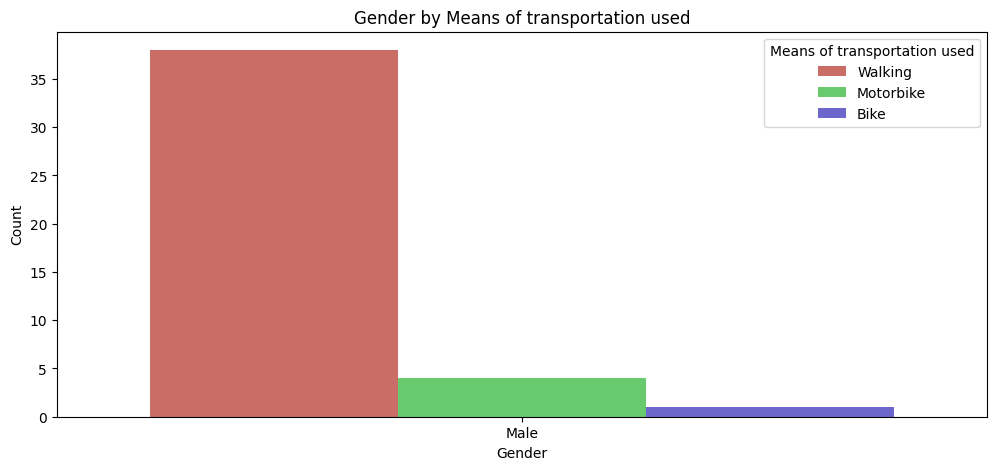

```python
figure(figsize=(12,	5))
countplot(data=GenderLte30AndWeightGte90AndMeansTrans2, x='Gender', hue='Means of transportation used', palette="hls")
title('Gender by Means of transportation used')
xlabel('Gender')
ylabel('Count')
show()
```

### **For Males**:

##### **Walking (Red Bar)**: Walking is the most frequently reported means of transportation among males shown in this chart, with a count of approximately 38.

##### **Motorbike (Green Bar)**: Motorbike usage is considerably less frequent than walking, with a count of around 4.

##### **Bike (Blue Bar)**: Bike usage is the least frequent among these three options for males, with a count of only 1.

### **Overall Observations for Males (based on this chart)**:

##### Walking is the dominant form of non-motorized/light motorized transportation reported by males in this subset of your data.

##### Motorbike usage is present but significantly lower than walking.

##### Bike usage is very minimal among the males represented here.

### **Important Considerations**:

##### This chart only shows data for males. There is no information about females and their usage of these transportation methods in this particular visualization.

##### The scale of the y-axis (Count) is relatively small (up to 40). This suggests that this chart might be focusing on a specific subset of your overall data or that these particular modes of transportation are not very common in the broader population you are studying, at least for males.

##### This is different from the previous chart which focused on Public Transportation and Automobile.

### **In summary, for the males represented in this specific chart:**

##### Walking is the most common of the three transportation methods shown.

##### Motorbike usage is present but much lower.

##### **Gender** with **Age > 30** and **Weight >= 90** and **Number of main meals the person eats per day = 3** or **4**

```python
GenderGt30AndWeightGte90AndNumberMealsPerDay1 = train_df.loc[(train_df['Age'] > 30) & (train_df['Weight'] >= 90) &
             ((train_df['Number of main meals the person eats per day'] == 3) | (train_df['Number of main meals the person eats per day'] == 4)) ,
             (['Age','Gender','Weight','Number of main meals the person eats per day'])]
```

```python
GenderGt30AndWeightGte90AndNumberMealsPerDay1
```

|  | Age | Gender | Weight | Number of main meals the person eats per day |
| --- | --- | --- | --- | --- |
| 46 | 31 | Male | 120.998266 | 3 |
| 102 | 31 | Male | 122.813033 | 3 |
| 203 | 35 | Female | 90.000000 | 3 |
| 206 | 32 | Male | 120.158049 | 3 |
| 208 | 32 | Male | 119.441207 | 3 |
| ... | ... | ... | ... | ... |
| 20553 | 32 | Male | 128.114161 | 3 |
| 20583 | 34 | Male | 91.059595 | 3 |
| 20598 | 31 | Male | 112.277567 | 3 |
| 20635 | 31 | Male | 120.919703 | 3 |
| 20710 | 34 | Male | 102.134646 | 3 |

760 rows × 4 columns

```python
GenderGt30AndWeightGte90AndNumberMealsPerDay1['Gender'].value_counts()
```

```
Gender
Male      756
Female      4
Name: count, dtype: int64
```

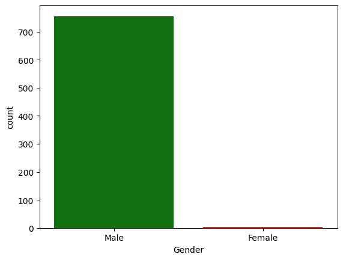

```python
countplot(x='Gender', data=GenderGt30AndWeightGte90AndNumberMealsPerDay1, palette=['green','red'])
xlabel('Gender')
show()
```

```python
GenderGt30AndWeightGte90AndNumberMealsPerDay1['Number of main meals the person eats per day'].value_counts()
```

```
Number of main meals the person eats per day
3    754
4      6
Name: count, dtype: int64
```

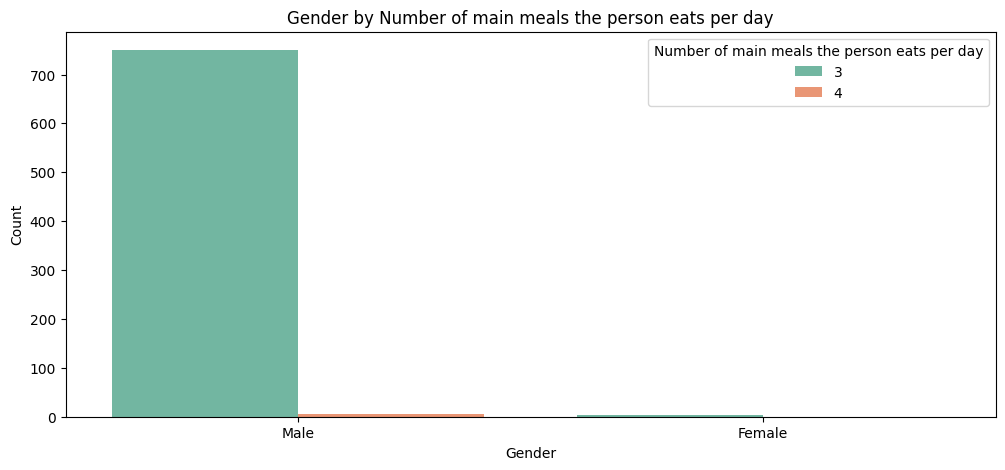

```python
figure(figsize=(12,	5))
countplot(data=GenderGt30AndWeightGte90AndNumberMealsPerDay1, x='Gender', hue='Number of main meals the person eats per day', palette="Set2")
title('Gender by Number of main meals the person eats per day')
xlabel('Gender')
ylabel('Count')
show()
```

### **For Males**:

##### **3 main meals per day (Teal Bar)**: A very high number of males reported eating 3 main meals per day, with a count of approximately 760.

##### **4 main meals per day (Salmon Bar)**: A very small number of males reported eating 4 main meals per day, with a count of less than 10.

### **For Females**:

##### **3 main meals per day (Teal Bar)**: A very small number of females reported eating 3 main meals per day, with a count of less than 10.

##### **4 main meals per day (Salmon Bar)**: The chart doesn't show a bar for females eating 4 main meals, implying the count is either zero or too small to be visible.

### Overall Observations:

##### Eating 3 main meals per day is overwhelmingly more common than eating 4 main meals per day in this subset of your data.

##### Males are much more likely to report eating 3 main meals per day compared to females.

##### Eating 4 main meals per day appears to be very rare for both genders in this specific view, but slightly more prevalent among the few who reported it were males.

### **Important Considerations**:

##### This chart only shows data for individuals reporting exactly 3 or 4 main meals. It doesn't include those who might eat fewer than 3 or more than 4 main meals.

##### The counts for females in both categories (and males eating 4 meals) are very low. This might indicate a genuine trend in your data or could be due to a smaller sample size for these specific categories.

### **In summary, based on this chart**:

##### **Gender** with **Age <= 30** and **Weight >= 90** and **Number of main meals the person eats per day = 3** or **4**

```python
GenderLte30AndWeightGte90AndNumberMealsPerDay2 = train_df.loc[(train_df['Age'] <= 30) & (train_df['Weight'] >= 90) &
             ((train_df['Number of main meals the person eats per day'] == 3) | (train_df['Number of main meals the person eats per day'] == 4)) ,
             (['Age','Gender','Weight','Number of main meals the person eats per day'])]
```

```python
GenderLte30AndWeightGte90AndNumberMealsPerDay2
```

|  | Age | Gender | Weight | Number of main meals the person eats per day |
| --- | --- | --- | --- | --- |
| 3 | 21 | Female | 131.274851 | 3 |
| 6 | 30 | Male | 112.725005 | 3 |
| 7 | 30 | Male | 118.206565 | 3 |
| 9 | 26 | Female | 111.275646 | 3 |
| 13 | 21 | Female | 131.529267 | 3 |
| ... | ... | ... | ... | ... |
| 20749 | 26 | Female | 104.835346 | 3 |
| 20751 | 21 | Female | 133.466763 | 3 |
| 20753 | 25 | Male | 114.187096 | 3 |
| 20755 | 20 | Male | 105.580491 | 3 |
| 20757 | 27 | Male | 118.134898 | 3 |

7376 rows × 4 columns

```python
GenderLte30AndWeightGte90AndNumberMealsPerDay2['Gender'].value_counts()
```

```
Gender
Female    4134
Male      3242
Name: count, dtype: int64
```

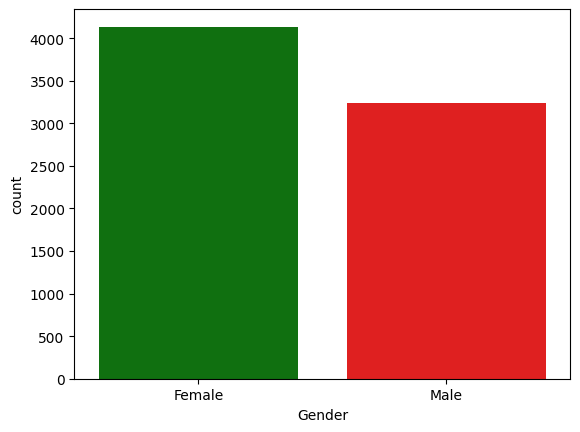

```python
countplot(x='Gender', data=GenderLte30AndWeightGte90AndNumberMealsPerDay2, palette=['green','red'])
xlabel('Gender')
show()
```

```python
GenderLte30AndWeightGte90AndNumberMealsPerDay2['Number of main meals the person eats per day'].value_counts()
```

```
Number of main meals the person eats per day
3    7355
4      21
Name: count, dtype: int64
```

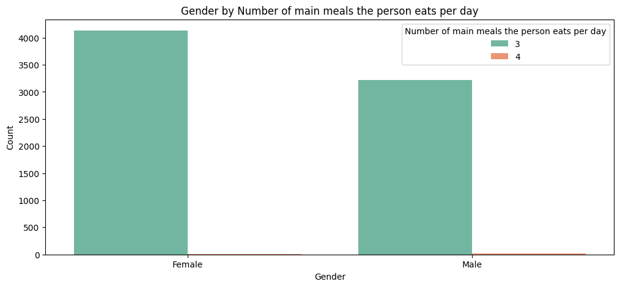

```python
figure(figsize=(12,	5))
countplot(data=GenderLte30AndWeightGte90AndNumberMealsPerDay2, x='Gender', hue='Number of main meals the person eats per day', palette="Set2")
title('Gender by Number of main meals the person eats per day')
xlabel('Gender')
ylabel('Count')
show()
```

### **For Females**:

##### **3 main meals per day (Teal Bar)**: A very high number of females reported eating 3 main meals per day, with a count of approximately 4150.

##### **4 main meals per day (Salmon Bar)**: A very small number of females reported eating 4 main meals per day, with a count very close to zero.

### **For Males**:

##### **3 main meals per day (Teal Bar)**: A substantial number of males also reported eating 3 main meals per day, with a count of approximately 3200. This is lower than the number of females reporting 3 meals.

##### **4 main meals per day (Salmon Bar)**: A very small number of males also reported eating 4 main meals per day, with a count very close to zero.

### **Overall Observations**:

##### Eating 3 main meals per day is the overwhelmingly dominant pattern for both genders in this view of data.

##### Females are more likely to report eating 3 main meals per day compared to males.

##### Eating 4 main meals per day is very rare for both genders based on this chart.

### **Comparison with the Previous Chart:**

##### The counts in this chart are significantly higher than in the previous one, suggesting this might represent a larger portion of dataset.

##### The trend remains the same: 3 main meals are much more common than 4, and females show a higher count for 3 meals compared to males.

### **In summary, based on this chart**:

##### The vast majority of both males and females in this dataset report eating 3 main meals per day.

##### A very small fraction of both genders report eating 4 main meals per day.

##### Females have a higher frequency of reporting 3 main meals per day compared to males.

##### **Gender** with **Age > 30** and **Weight >= 90** and **Physical activity frequency Classes = No physical activity** or **Very low activity**

```python
GenderGt30AndWeightGte90AndPhysicalActivity1 = train_df.loc[(train_df['Age'] > 30) & (train_df['Weight'] >= 90) &
             ((train_df['Physical activity frequency Classes'] == 'No physical activity') | (train_df['Physical activity frequency Classes'] == 'Very low activity')) ,
             (['Age','Gender','Weight','Physical activity frequency Classes'])]
```

```python
GenderGt30AndWeightGte90AndPhysicalActivity1
```

|  | Age | Gender | Weight | Physical activity frequency Classes |
| --- | --- | --- | --- | --- |
| 4 | 32 | Male | 93.798055 | Very low activity |
| 46 | 31 | Male | 120.998266 | Very low activity |
| 102 | 31 | Male | 122.813033 | No physical activity |
| 103 | 32 | Male | 90.000000 | Very low activity |
| 203 | 35 | Female | 90.000000 | Very low activity |
| ... | ... | ... | ... | ... |
| 20547 | 31 | Male | 118.424156 | No physical activity |
| 20553 | 32 | Male | 128.114161 | No physical activity |
| 20598 | 31 | Male | 112.277567 | No physical activity |
| 20635 | 31 | Male | 120.919703 | No physical activity |
| 20710 | 34 | Male | 102.134646 | Very low activity |

932 rows × 4 columns

```python
GenderGt30AndWeightGte90AndPhysicalActivity1['Gender'].value_counts()
```

```
Gender
Male      926
Female      6
Name: count, dtype: int64
```

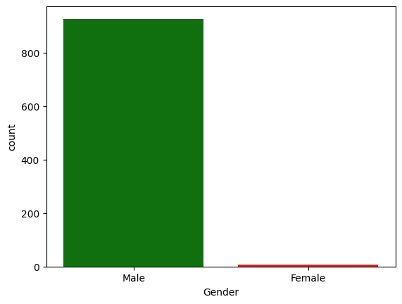

```python
countplot(x='Gender', data=GenderGt30AndWeightGte90AndPhysicalActivity1, palette=['green','red'])
xlabel('Gender')
show()
```

```python
GenderGt30AndWeightGte90AndPhysicalActivity1['Physical activity frequency Classes'].value_counts()
```

```
Physical activity frequency Classes
No physical activity    494
Very low activity       438
Name: count, dtype: int64
```

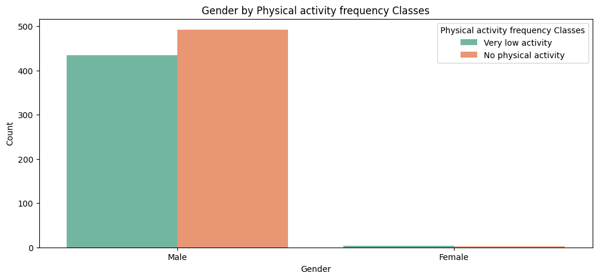

```python
figure(figsize=(12,	5))
countplot(data=GenderGt30AndWeightGte90AndPhysicalActivity1, x='Gender', hue='Physical activity frequency Classes', palette="Set2")
title('Gender by Physical activity frequency Classes')
xlabel('Gender')
ylabel('Count')
show()
```

### **For Males**:

##### **Very low activity (Teal Bar):** A significant number of males are classified as having "Very low activity," with a count of approximately 435.

##### **No physical activity (Salmon Bar)**: An even larger number of males are classified as having "No physical activity," with a count of approximately 490.

### **For Females**:

##### **Very low activity (Teal Bar)**: A very small number of females are classified as having "Very low activity," with a count close to zero but slightly above it.

##### **No physical activity (Salmon Bar)**: A very small number of females are also classified as having "No physical activity," with a count close to zero but slightly above it.

### **Overall Observations (focusing on these two activity levels)**:

##### **For males**, "No physical activity" is slightly more prevalent than "Very low activity."

##### **For females**, both "Very low activity" and "No physical activity" are very rare compared to males. The counts are close to zero on the scale of this chart.

##### There is a substantial gender difference in the prevalence of these lower levels of physical activity. Males show considerably higher counts in both the "Very low activity" and "No physical activity" categories compared to females.

##### Important Considerations:

##### This chart only focuses on two specific categories of physical activity frequency. It doesn't provide information about individuals with "Low to moderate activity" or "Moderate activity."

##### The scale of the y-axis (Count) goes up to 500. This allows us to see the relative differences between male counts and the very low female counts.

### **In summary, based on this chart**:

##### Among males, "No physical activity" is slightly more common than "Very low activity."

##### Both "Very low activity" and "No physical activity" appear to be uncommon among females in this specific view of the data.

##### Males in this dataset are much more likely to report either "Very low activity" or "No physical activity" compared to females.

##### **Gender** with **Age <= 30** and **Weight >= 90** and **Physical activity frequency Classes = No physical activity** or **Very low activity**

```python
GenderLte30AndWeightGte90AndPhysicalActivity1 = train_df.loc[(train_df['Age'] <= 30) & (train_df['Weight'] >= 90) &
             ((train_df['Physical activity frequency Classes'] == 'No physical activity') | (train_df['Physical activity frequency Classes'] == 'Very low activity')) ,
             (['Age','Gender','Weight','Physical activity frequency Classes'])]
```

```python
GenderLte30AndWeightGte90AndPhysicalActivity1
```

|  | Age | Gender | Weight | Physical activity frequency Classes |
| --- | --- | --- | --- | --- |
| 3 | 21 | Female | 131.274851 | Very low activity |
| 6 | 30 | Male | 112.725005 | No physical activity |
| 7 | 30 | Male | 118.206565 | No physical activity |
| 9 | 26 | Female | 111.275646 | No physical activity |
| 12 | 18 | Male | 108.251044 | Very low activity |
| ... | ... | ... | ... | ... |
| 20749 | 26 | Female | 104.835346 | No physical activity |
| 20751 | 21 | Female | 133.466763 | Very low activity |
| 20753 | 25 | Male | 114.187096 | Very low activity |
| 20755 | 20 | Male | 105.580491 | Very low activity |
| 20757 | 27 | Male | 118.134898 | No physical activity |

7555 rows × 4 columns

```python
GenderLte30AndWeightGte90AndPhysicalActivity1['Gender'].value_counts()
```

```
Gender
Female    4133
Male      3422
Name: count, dtype: int64
```

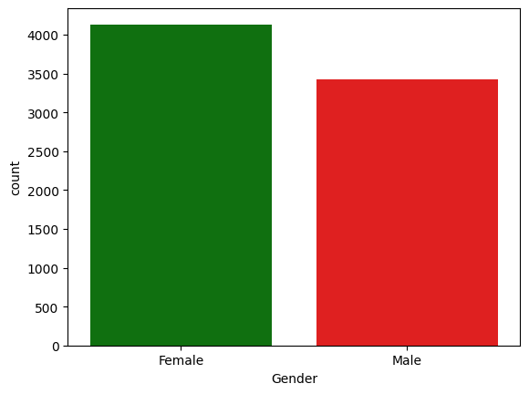

```python
countplot(x='Gender', data=GenderLte30AndWeightGte90AndPhysicalActivity1, palette=['green','red'])
xlabel('Gender')
show()
```

```python
GenderLte30AndWeightGte90AndPhysicalActivity1['Physical activity frequency Classes'].value_counts()
```

```
Physical activity frequency Classes
No physical activity    4351
Very low activity       3204
Name: count, dtype: int64
```

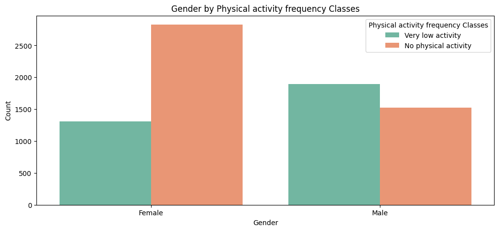

```python
figure(figsize=(12,	5))
countplot(data=GenderLte30AndWeightGte90AndPhysicalActivity1, x='Gender', hue='Physical activity frequency Classes', palette="Set2")
title('Gender by Physical activity frequency Classes')
xlabel('Gender')
ylabel('Count')
show()
```

### **For Females**:

##### **Very low activity (Teal Bar)**: Approximately 1300 females are classified as having "Very low activity."

##### **No physical activity (Salmon Bar)**: A much larger number of females are classified as having "No physical activity," with a count of around 2850.

### **For Males**:

##### **Very low activity (Teal Bar)**: Approximately 1900 males are classified as having "Very low activity." This is higher than the number of females in the same category.

##### **No physical activity (Salmon Bar)**: Approximately 1500 males are classified as having "No physical activity." This is lower than the number of females in the same category.

### **Overall Observations (focusing on these two activity levels)**:

##### **For females**, "No physical activity" is significantly more prevalent than "Very low activity."

##### **For males**, "Very low activity" is more prevalent than "No physical activity."

##### There is a clear gender difference in the distribution of these lower levels of physical activity. A higher proportion of females in this view report "No physical activity," while a higher proportion of males report "Very low activity."

### **Important Considerations**:

##### This chart only focuses on two specific categories of physical activity frequency. It doesn't provide information about individuals with "Low to moderate activity" or "Moderate activity."

##### The scale of the y-axis (Count) goes up to 3000. This allows us to see the substantial counts in these categories.

### **In summary, based on this chart**:

##### **Among females**, the dominant lower physical activity level is "No physical activity."

##### **Among males**, the more common lower physical activity level is "Very low activity."

##### Females in dataset are more likely to report "No physical activity" compared to males, while males are more likely to report "Very low activity" compared to females, within these two categories.

##### **Gender** with **Age > 30** and **Weight >= 90** and **Physical activity frequency Classes = Low to moderate activity** or **Moderate activity**

```python
GenderGt30AndWeightGte90AndPhysicalActivity2 = train_df.loc[(train_df['Age'] > 30) & (train_df['Weight'] >= 90) &
             ((train_df['Physical activity frequency Classes'] == 'Low to moderate activity') | (train_df['Physical activity frequency Classes'] == 'Moderate activity')) ,
             (['Age','Gender','Weight','Physical activity frequency Classes'])]
```

```python
GenderGt30AndWeightGte90AndPhysicalActivity2
```

|  | Age | Gender | Weight | Physical activity frequency Classes |
| --- | --- | --- | --- | --- |
| 460 | 33 | Male | 97.000000 | Low to moderate activity |
| 2612 | 34 | Male | 90.000000 | Low to moderate activity |
| 3547 | 33 | Male | 97.000000 | Low to moderate activity |
| 4438 | 34 | Male | 120.000000 | Low to moderate activity |
| 5920 | 32 | Male | 102.781971 | Low to moderate activity |
| 5923 | 34 | Male | 98.790167 | Low to moderate activity |
| 6454 | 33 | Male | 97.813023 | Low to moderate activity |
| 6460 | 33 | Male | 97.544696 | Low to moderate activity |
| 7186 | 33 | Male | 97.592949 | Low to moderate activity |
| 7474 | 33 | Male | 97.000000 | Moderate activity |
| 8032 | 32 | Male | 105.800158 | Low to moderate activity |
| 8206 | 33 | Male | 97.000000 | Low to moderate activity |
| 8575 | 32 | Male | 101.544589 | Low to moderate activity |
| 9519 | 33 | Male | 107.559630 | Low to moderate activity |
| 11334 | 33 | Male | 97.000000 | Low to moderate activity |
| 14456 | 33 | Male | 93.310284 | Low to moderate activity |
| 15760 | 33 | Male | 90.000000 | Low to moderate activity |
| 16534 | 35 | Male | 98.543020 | Low to moderate activity |
| 16572 | 34 | Male | 90.000000 | Low to moderate activity |
| 16666 | 35 | Male | 90.471683 | Low to moderate activity |
| 16781 | 34 | Male | 99.000000 | Low to moderate activity |
| 17502 | 34 | Male | 100.000000 | Low to moderate activity |
| 17570 | 33 | Male | 97.000000 | Moderate activity |
| 17672 | 33 | Male | 91.000000 | Low to moderate activity |
| 17804 | 34 | Male | 103.970612 | Low to moderate activity |
| 17867 | 33 | Male | 113.000000 | Low to moderate activity |
| 18566 | 35 | Male | 103.669116 | Low to moderate activity |
| 20583 | 34 | Male | 91.059595 | Low to moderate activity |
| 20747 | 33 | Male | 99.000000 | Low to moderate activity |

```python
GenderGt30AndWeightGte90AndPhysicalActivity2['Gender'].value_counts()
```

```
Gender
Male    29
Name: count, dtype: int64
```

```python
GenderGt30AndWeightGte90AndPhysicalActivity2['Physical activity frequency Classes'].value_counts()
```

```
Physical activity frequency Classes
Low to moderate activity    27
Moderate activity            2
Name: count, dtype: int64
```

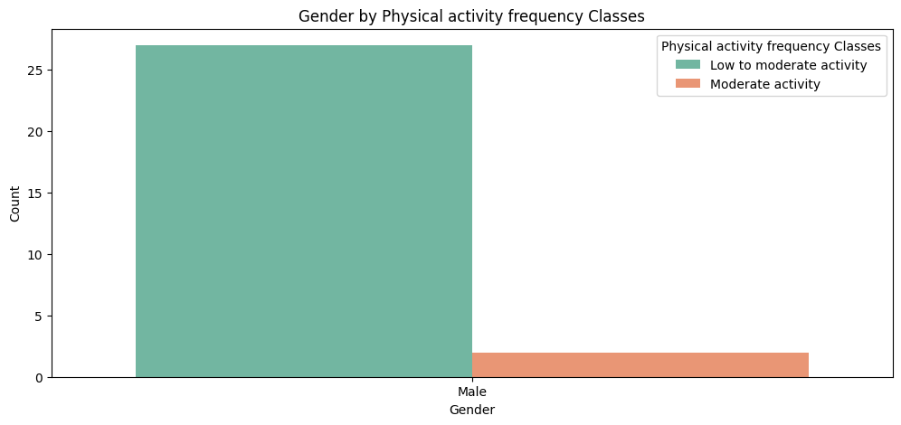

```python
figure(figsize=(12,	5))
countplot(data=GenderGt30AndWeightGte90AndPhysicalActivity2, x='Gender', hue='Physical activity frequency Classes', palette="Set2")
title('Gender by Physical activity frequency Classes')
xlabel('Gender')
ylabel('Count')
show()
```

### **For Males**:

##### **Low to moderate activity (Teal Bar)**: Approximately 27 males are classified as having "Low to moderate activity."

##### **Moderate activity (Salmon Bar)**: Approximately 2 males are classified as having "Moderate activity."

### Overall Observations for Males (based on this chart):

##### Within these two higher activity categories, "Low to moderate activity" is significantly more prevalent among males compared to "Moderate activity."

### **Important Considerations**:

##### This chart only shows data for males. There is no information about females and their activity levels in these categories in this particular visualization.

##### The scale of the y-axis (Count) is relatively small (up to 30). This suggests that these higher activity levels might be less common in the male subset represented here compared to the lower activity levels we saw in previous charts.

##### This is another slice of the overall physical activity frequency data by gender.

### **In summary, for the males represented in this specific chart**:

##### "Low to moderate activity" is reported by a noticeable number of individuals.

##### "Moderate activity" is reported by a much smaller number of individuals.

##### **Gender** with **Age <= 30** and **Weight >= 90** and **Physical activity frequency Classes = Low to moderate activity** or **Moderate activity**

```python
GenderLte30AndWeightGte90AndPhysicalActivity2 = train_df.loc[(train_df['Age'] <= 30) & (train_df['Weight'] >= 90) &
             ((train_df['Physical activity frequency Classes'] == 'Low to moderate activity') | (train_df['Physical activity frequency Classes'] == 'Moderate activity')) ,
             (['Age','Gender','Weight','Physical activity frequency Classes'])]
```

```python
GenderLte30AndWeightGte90AndPhysicalActivity2
```

|  | Age | Gender | Weight | Physical activity frequency Classes |
| --- | --- | --- | --- | --- |
| 31 | 23 | Male | 97.000000 | Moderate activity |
| 79 | 22 | Male | 105.000000 | Low to moderate activity |
| 99 | 18 | Male | 95.000000 | Low to moderate activity |
| 110 | 22 | Male | 95.000000 | Moderate activity |
| 143 | 20 | Male | 105.025808 | Low to moderate activity |
| ... | ... | ... | ... | ... |
| 20550 | 26 | Male | 103.000000 | Moderate activity |
| 20614 | 18 | Male | 90.000000 | Low to moderate activity |
| 20713 | 25 | Male | 114.000000 | Low to moderate activity |
| 20729 | 22 | Male | 98.447311 | Low to moderate activity |
| 20741 | 22 | Male | 105.037203 | Low to moderate activity |

431 rows × 4 columns

```python
GenderLte30AndWeightGte90AndPhysicalActivity2['Gender'].value_counts()
```

```
Gender
Male      413
Female     18
Name: count, dtype: int64
```

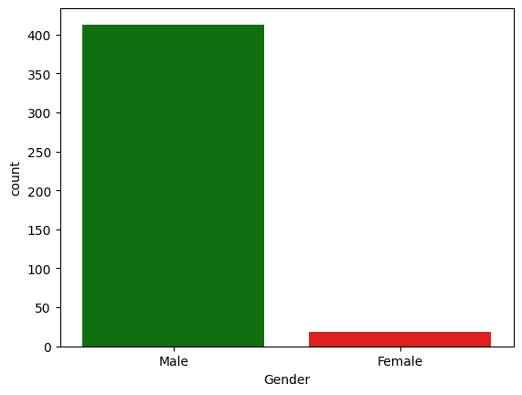

```python
countplot(x='Gender', data=GenderLte30AndWeightGte90AndPhysicalActivity2, palette=['green','red'])
xlabel('Gender')
show()
```

```python
GenderLte30AndWeightGte90AndPhysicalActivity2['Physical activity frequency Classes'].value_counts()
```

```
Physical activity frequency Classes
Low to moderate activity    288
Moderate activity           143
Name: count, dtype: int64
```

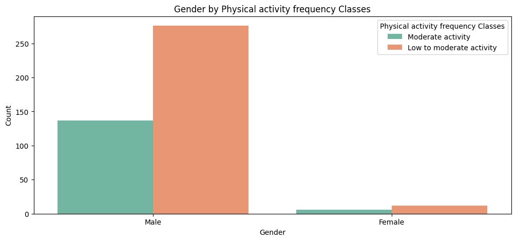

```python
figure(figsize=(12,	5))
countplot(data=GenderLte30AndWeightGte90AndPhysicalActivity2, x='Gender', hue='Physical activity frequency Classes', palette="Set2")
title('Gender by Physical activity frequency Classes')
xlabel('Gender')
ylabel('Count')
show()
```

### **For Males**:

##### **Moderate activity (Teal Bar)**: Approximately 135 males are classified as having "Moderate activity."

##### **Low to moderate activity (Salmon Bar)**: A much larger number of males are classified as having "Low to moderate activity," with a count of around 280.

### **For Females**:

##### **Moderate activity (Teal Bar)**: A very small number of females are classified as having "Moderate activity," with a count of less than 10.

##### **Low to moderate activity (Salmon Bar)**: A small number of females are classified as having "Low to moderate activity," with a count of around 12.

### **Overall Observations (focusing on these two activity levels)**:

##### **For males**, "Low to moderate activity" is considerably more prevalent than "Moderate activity."

##### **For females**, both "Moderate activity" and "Low to moderate activity" have very low counts compared to males.

##### There is a substantial gender difference in the prevalence of these higher levels of physical activity. Males show much higher counts in both the "Moderate activity" and "Low to moderate activity" categories compared to females.

### **Important Considerations:**

##### This chart only focuses on two specific categories of physical activity frequency. It doesn't provide information about individuals with "No physical activity" or "Very low activity."

##### The scale of the y-axis (Count) goes up to 300. This allows us to see the relative differences between male and female counts in these categories.

### **In summary, based on this chart**:

##### Among males, "Low to moderate activity" is the more common of the two higher activity levels shown.

##### Both "Moderate activity" and "Low to moderate activity" are relatively rare among females in this specific view of the data.

##### Males in dataset are much more likely to report "Moderate activity" or "Low to moderate activity" compared to females.

## **Transform Data**

##### **Spliting data to number and object**

```python
object_train_data = train_df.select_dtypes(include='object')
non_object_train_data = train_df.select_dtypes(exclude='object')
```

```python
object_train_data
```

|  | Gender | Family history with overweight | Frequent consumption of high-caloric food | Consumption of food between meals | SMOKE | Whether the person takes calorie supplements | Alcohol consumption | Means of transportation used | Obesity level class | Frequency of vegetable consumption Classes | Number of main meals the person eats per day Classes | Daily water consumption Classes | Physical activity frequency Classes | Time spent using technology Classes |
| --- | --- | --- | --- | --- | --- | --- | --- | --- | --- | --- | --- | --- | --- | --- |
| 0 | Male | yes | yes | Sometimes | no | no | Sometimes | Public_Transportation | Overweight_Level_II | Sometimes consumes vegetables | Three meals per day | Moderate water intake | No physical activity | Very low screen time |
| 1 | Female | yes | yes | Frequently | no | no | no | Automobile | Normal_Weight | Sometimes consumes vegetables | Three meals per day | Moderate water intake | Very low activity | Very low screen time |
| 2 | Female | yes | yes | Sometimes | no | no | no | Public_Transportation | Insufficient_Weight | Sometimes consumes vegetables | One meal per day | Low water intake | No physical activity | Very low screen time |
| 3 | Female | yes | yes | Sometimes | no | no | Sometimes | Public_Transportation | Obesity_Type_III | Regularly consumes vegetables | Three meals per day | Low water intake | Very low activity | Very low screen time |
| 4 | Male | yes | yes | Sometimes | no | no | Sometimes | Public_Transportation | Overweight_Level_II | Regularly consumes vegetables | Two meals per day | Low water intake | Very low activity | Very low screen time |
| ... | ... | ... | ... | ... | ... | ... | ... | ... | ... | ... | ... | ... | ... | ... |
| 20753 | Male | yes | yes | Sometimes | no | no | Sometimes | Public_Transportation | Obesity_Type_II | Regularly consumes vegetables | Three meals per day | Moderate water intake | Very low activity | Very low screen time |
| 20754 | Male | no | yes | Frequently | no | no | Sometimes | Public_Transportation | Insufficient_Weight | Regularly consumes vegetables | More than three meals | Low water intake | Low to moderate activity | Very low screen time |
| 20755 | Male | yes | yes | Sometimes | no | no | no | Public_Transportation | Obesity_Type_II | Sometimes consumes vegetables | Three meals per day | Moderate water intake | Very low activity | Very low screen time |
| 20756 | Male | yes | yes | Sometimes | no | no | no | Automobile | Overweight_Level_II | Regularly consumes vegetables | Two meals per day | Moderate water intake | No physical activity | Very low screen time |
| 20757 | Male | yes | yes | Sometimes | no | no | Sometimes | Public_Transportation | Obesity_Type_II | Regularly consumes vegetables | Three meals per day | Moderate water intake | No physical activity | Very low screen time |

19729 rows × 14 columns

##### **Spliting object data to object data with 2 uniques and object data Gt 2 uniques**

```python
for col in object_train_data.columns:
    if object_train_data[col].nunique() == 2  :
        print(f'{col} : {object_train_data[col].nunique()}')
```

```
Gender : 2
Family history with overweight : 2
Frequent consumption of high-caloric food : 2
SMOKE : 2
Whether the person takes calorie supplements : 2
Time spent using technology Classes : 2
```

```python
object_train_data_with_2_uniques = object_train_data[['Gender','Family history with overweight','Frequent consumption of high-caloric food','SMOKE',
                                                      'Whether the person takes calorie supplements','Time spent using technology Classes']]
```

```python
label = LabelEncoder()
for col in range(0,object_train_data_with_2_uniques.shape[1]):
    object_train_data_with_2_uniques.iloc[:,col] = label.fit_transform(object_train_data_with_2_uniques.iloc[:,col])
object_train_data_with_2_uniques = object_train_data_with_2_uniques.astype(int)
```

```python
object_train_data_with_2_uniques
```

|  | Gender | Family history with overweight | Frequent consumption of high-caloric food | SMOKE | Whether the person takes calorie supplements | Time spent using technology Classes |
| --- | --- | --- | --- | --- | --- | --- |
| 0 | 1 | 1 | 1 | 0 | 0 | 1 |
| 1 | 0 | 1 | 1 | 0 | 0 | 1 |
| 2 | 0 | 1 | 1 | 0 | 0 | 1 |
| 3 | 0 | 1 | 1 | 0 | 0 | 1 |
| 4 | 1 | 1 | 1 | 0 | 0 | 1 |
| ... | ... | ... | ... | ... | ... | ... |
| 20753 | 1 | 1 | 1 | 0 | 0 | 1 |
| 20754 | 1 | 0 | 1 | 0 | 0 | 1 |
| 20755 | 1 | 1 | 1 | 0 | 0 | 1 |
| 20756 | 1 | 1 | 1 | 0 | 0 | 1 |
| 20757 | 1 | 1 | 1 | 0 | 0 | 1 |

19729 rows × 6 columns

```python
object_train_data_with_2_uniques.info()
```

```
<class 'pandas.core.frame.DataFrame'>
Index: 19729 entries, 0 to 20757
Data columns (total 6 columns):
 #   Column                                        Non-Null Count  Dtype
---  ------                                        --------------  -----
 0   Gender                                        19729 non-null  int32
 1   Family history with overweight                19729 non-null  int32
 2   Frequent consumption of high-caloric food     19729 non-null  int32
 3   SMOKE                                         19729 non-null  int32
 4   Whether the person takes calorie supplements  19729 non-null  int32
 5   Time spent using technology Classes           19729 non-null  int32
dtypes: int32(6)
memory usage: 616.5 KB
```

```python
# # saving label
# with open('label.pkl' , 'wb') as f :
#     dump(label, f)
```

```python
for col in object_train_data.columns:
    if object_train_data[col].nunique()  > 2 :
        print(f'{col} : {object_train_data[col].nunique()}')
```

```
Consumption of food between meals : 4
Alcohol consumption : 3
Means of transportation used : 5
Obesity level class : 7
Frequency of vegetable consumption Classes : 3
Number of main meals the person eats per day Classes : 4
Daily water consumption Classes : 3
Physical activity frequency Classes : 4
```

```python
object_train_data_Gt_2_nuniques = object_train_data[['Consumption of food between meals','Alcohol consumption','Means of transportation used','Obesity level class','Frequency of vegetable consumption Classes','Number of main meals the person eats per day Classes','Daily water consumption Classes','Physical activity frequency Classes']]
```

```python
object_train_data_Gt_2_nuniques
```

|  | Consumption of food between meals | Alcohol consumption | Means of transportation used | Obesity level class | Frequency of vegetable consumption Classes | Number of main meals the person eats per day Classes | Daily water consumption Classes | Physical activity frequency Classes |
| --- | --- | --- | --- | --- | --- | --- | --- | --- |
| 0 | Sometimes | Sometimes | Public_Transportation | Overweight_Level_II | Sometimes consumes vegetables | Three meals per day | Moderate water intake | No physical activity |
| 1 | Frequently | no | Automobile | Normal_Weight | Sometimes consumes vegetables | Three meals per day | Moderate water intake | Very low activity |
| 2 | Sometimes | no | Public_Transportation | Insufficient_Weight | Sometimes consumes vegetables | One meal per day | Low water intake | No physical activity |
| 3 | Sometimes | Sometimes | Public_Transportation | Obesity_Type_III | Regularly consumes vegetables | Three meals per day | Low water intake | Very low activity |
| 4 | Sometimes | Sometimes | Public_Transportation | Overweight_Level_II | Regularly consumes vegetables | Two meals per day | Low water intake | Very low activity |
| ... | ... | ... | ... | ... | ... | ... | ... | ... |
| 20753 | Sometimes | Sometimes | Public_Transportation | Obesity_Type_II | Regularly consumes vegetables | Three meals per day | Moderate water intake | Very low activity |
| 20754 | Frequently | Sometimes | Public_Transportation | Insufficient_Weight | Regularly consumes vegetables | More than three meals | Low water intake | Low to moderate activity |
| 20755 | Sometimes | no | Public_Transportation | Obesity_Type_II | Sometimes consumes vegetables | Three meals per day | Moderate water intake | Very low activity |
| 20756 | Sometimes | no | Automobile | Overweight_Level_II | Regularly consumes vegetables | Two meals per day | Moderate water intake | No physical activity |
| 20757 | Sometimes | Sometimes | Public_Transportation | Obesity_Type_II | Regularly consumes vegetables | Three meals per day | Moderate water intake | No physical activity |

19729 rows × 8 columns

```python
object_train_data_Gt_2_nuniques['Frequency of vegetable consumption Classes'].value_counts()
```

```
Frequency of vegetable consumption Classes
Regularly consumes vegetables    9783
Sometimes consumes vegetables    9196
Rarely consumes vegetables        750
Name: count, dtype: int64
```

```python
object_train_data_Gt_2_nuniques['Frequency of vegetable consumption Classes']= object_train_data_Gt_2_nuniques['Frequency of vegetable consumption Classes'].replace('Rarely consumes vegetables',0)
object_train_data_Gt_2_nuniques['Frequency of vegetable consumption Classes']= object_train_data_Gt_2_nuniques['Frequency of vegetable consumption Classes'].replace('Sometimes consumes vegetables',1)
object_train_data_Gt_2_nuniques['Frequency of vegetable consumption Classes']= object_train_data_Gt_2_nuniques['Frequency of vegetable consumption Classes'].replace('Regularly consumes vegetables',2)
```

```python
object_train_data_Gt_2_nuniques['Frequency of vegetable consumption Classes'].value_counts()
```

```
Frequency of vegetable consumption Classes
2    9783
1    9196
0     750
Name: count, dtype: int64
```

```python
object_train_data_Gt_2_nuniques['Number of main meals the person eats per day Classes'].value_counts()
```

```
Number of main meals the person eats per day Classes
Three meals per day      15521
One meal per day          2357
More than three meals     1030
Two meals per day          821
Name: count, dtype: int64
```

```python
object_train_data_Gt_2_nuniques['Number of main meals the person eats per day Classes']= object_train_data_Gt_2_nuniques['Number of main meals the person eats per day Classes'].replace('One meal per day',0)
object_train_data_Gt_2_nuniques['Number of main meals the person eats per day Classes']= object_train_data_Gt_2_nuniques['Number of main meals the person eats per day Classes'].replace('Two meals per day',1)
object_train_data_Gt_2_nuniques['Number of main meals the person eats per day Classes']= object_train_data_Gt_2_nuniques['Number of main meals the person eats per day Classes'].replace('Three meals per day',2)
object_train_data_Gt_2_nuniques['Number of main meals the person eats per day Classes']= object_train_data_Gt_2_nuniques['Number of main meals the person eats per day Classes'].replace('More than three meals',3)
```

```python
object_train_data_Gt_2_nuniques['Number of main meals the person eats per day Classes'].value_counts()
```

```
Number of main meals the person eats per day Classes
2    15521
0     2357
3     1030
1      821
Name: count, dtype: int64
```

```python
object_train_data_Gt_2_nuniques['Daily water consumption Classes'].value_counts()
```

```
Daily water consumption Classes
Moderate water intake    12601
Low water intake          5599
High water intake         1529
Name: count, dtype: int64
```

```python
object_train_data_Gt_2_nuniques['Daily water consumption Classes']= object_train_data_Gt_2_nuniques['Daily water consumption Classes'].replace('Low water intake',0)
object_train_data_Gt_2_nuniques['Daily water consumption Classes']= object_train_data_Gt_2_nuniques['Daily water consumption Classes'].replace('Moderate water intake',1)
object_train_data_Gt_2_nuniques['Daily water consumption Classes']= object_train_data_Gt_2_nuniques['Daily water consumption Classes'].replace('High water intake',2)
```

```python
object_train_data_Gt_2_nuniques['Daily water consumption Classes'].value_counts()
```

```
Daily water consumption Classes
1    12601
0     5599
2     1529
Name: count, dtype: int64
```

```python
object_train_data_Gt_2_nuniques['Physical activity frequency Classes'].value_counts()
```

```
Physical activity frequency Classes
No physical activity        8514
Very low activity           7657
Low to moderate activity    2784
Moderate activity            774
Name: count, dtype: int64
```

```python
object_train_data_Gt_2_nuniques['Physical activity frequency Classes']= object_train_data_Gt_2_nuniques['Physical activity frequency Classes'].replace('No physical activity',0)
object_train_data_Gt_2_nuniques['Physical activity frequency Classes']= object_train_data_Gt_2_nuniques['Physical activity frequency Classes'].replace('Very low activity',1)
object_train_data_Gt_2_nuniques['Physical activity frequency Classes']= object_train_data_Gt_2_nuniques['Physical activity frequency Classes'].replace('Low to moderate activity',2)
object_train_data_Gt_2_nuniques['Physical activity frequency Classes']= object_train_data_Gt_2_nuniques['Physical activity frequency Classes'].replace('Moderate activity',3)
```

```python
object_train_data_Gt_2_nuniques['Physical activity frequency Classes'].value_counts()
```

```
Physical activity frequency Classes
0    8514
1    7657
2    2784
3     774
Name: count, dtype: int64
```

```python
object_train_data_Gt_2_nuniques['Consumption of food between meals'].value_counts()
```

```
Consumption of food between meals
Sometimes     16566
Frequently     2425
Always          460
no              278
Name: count, dtype: int64
```

```python
object_train_data_Gt_2_nuniques['Consumption of food between meals']= object_train_data_Gt_2_nuniques['Consumption of food between meals'].replace('no',0)
object_train_data_Gt_2_nuniques['Consumption of food between meals']= object_train_data_Gt_2_nuniques['Consumption of food between meals'].replace('Sometimes',1)
object_train_data_Gt_2_nuniques['Consumption of food between meals']= object_train_data_Gt_2_nuniques['Consumption of food between meals'].replace('Frequently',2)
object_train_data_Gt_2_nuniques['Consumption of food between meals']= object_train_data_Gt_2_nuniques['Consumption of food between meals'].replace('Always',3)
```

```python
object_train_data_Gt_2_nuniques['Consumption of food between meals'].value_counts()
```

```
Consumption of food between meals
1    16566
2     2425
3      460
0      278
Name: count, dtype: int64
```

```python
object_train_data_Gt_2_nuniques['Alcohol consumption'].value_counts()
```

```
Alcohol consumption
Sometimes     14386
no             4872
Frequently      471
Name: count, dtype: int64
```

```python
object_train_data_Gt_2_nuniques['Alcohol consumption']= object_train_data_Gt_2_nuniques['Alcohol consumption'].replace('no',0)
object_train_data_Gt_2_nuniques['Alcohol consumption']= object_train_data_Gt_2_nuniques['Alcohol consumption'].replace('Sometimes',1)
object_train_data_Gt_2_nuniques['Alcohol consumption']= object_train_data_Gt_2_nuniques['Alcohol consumption'].replace('Frequently',2)
```

```python
object_train_data_Gt_2_nuniques['Alcohol consumption'].value_counts()
```

```
Alcohol consumption
1    14386
0     4872
2      471
Name: count, dtype: int64
```

```python
object_train_data_Gt_2_nuniques['Means of transportation used'].value_counts()
```

```
Means of transportation used
Public_Transportation    16669
Automobile                2537
Walking                    461
Motorbike                   32
Bike                        30
Name: count, dtype: int64
```

```python
object_train_data_Gt_2_nuniques['Means of transportation used']= object_train_data_Gt_2_nuniques['Means of transportation used'].replace('Public_Transportation',0)
object_train_data_Gt_2_nuniques['Means of transportation used']= object_train_data_Gt_2_nuniques['Means of transportation used'].replace('Automobile',1)
object_train_data_Gt_2_nuniques['Means of transportation used']= object_train_data_Gt_2_nuniques['Means of transportation used'].replace('Walking',2)
object_train_data_Gt_2_nuniques['Means of transportation used']= object_train_data_Gt_2_nuniques['Means of transportation used'].replace('Motorbike',3)
object_train_data_Gt_2_nuniques['Means of transportation used']= object_train_data_Gt_2_nuniques['Means of transportation used'].replace('Bike',4)
```

[output not shown]

```python
object_train_data_Gt_2_nuniques['Means of transportation used'].value_counts()
```

```
Means of transportation used
0    16669
1     2537
2      461
3       32
4       30
Name: count, dtype: int64
```

```python
object_train_data_Gt_2_nuniques['Obesity level class'].value_counts()
```

```
Obesity level class
Obesity_Type_III       4046
Obesity_Type_II        3067
Normal_Weight          3062
Insufficient_Weight    2516
Obesity_Type_I         2425
Overweight_Level_II    2325
Overweight_Level_I     2288
Name: count, dtype: int64
```

```python
object_train_data_Gt_2_nuniques['Obesity level class'] = object_train_data_Gt_2_nuniques['Obesity level class'].replace('Insufficient_Weight',0)
object_train_data_Gt_2_nuniques['Obesity level class'] = object_train_data_Gt_2_nuniques['Obesity level class'].replace('Normal_Weight',1)
object_train_data_Gt_2_nuniques['Obesity level class'] = object_train_data_Gt_2_nuniques['Obesity level class'].replace('Overweight_Level_I',2)
object_train_data_Gt_2_nuniques['Obesity level class'] = object_train_data_Gt_2_nuniques['Obesity level class'].replace('Overweight_Level_II',3)
object_train_data_Gt_2_nuniques['Obesity level class'] = object_train_data_Gt_2_nuniques['Obesity level class'].replace('Obesity_Type_I',4)
object_train_data_Gt_2_nuniques['Obesity level class'] = object_train_data_Gt_2_nuniques['Obesity level class'].replace('Obesity_Type_II',5)
object_train_data_Gt_2_nuniques['Obesity level class'] = object_train_data_Gt_2_nuniques['Obesity level class'].replace('Obesity_Type_III',6)
```

[output not shown]

```python
object_train_data_Gt_2_nuniques['Obesity level class'].value_counts()
```

```
Obesity level class
6    4046
5    3067
1    3062
0    2516
4    2425
3    2325
2    2288
Name: count, dtype: int64
```

```python
df=concat([non_object_train_data, object_train_data_with_2_uniques, object_train_data_Gt_2_nuniques],axis=1)
```

```python
df
```

|  | Age | Height | Weight | Frequency of vegetable consumption | Number of main meals the person eats per day | Daily water consumption | Physical activity frequency | Time spent using technology | Gender | Family history with overweight | ... | Whether the person takes calorie supplements | Time spent using technology Classes | Consumption of food between meals | Alcohol consumption | Means of transportation used | Obesity level class | Frequency of vegetable consumption Classes | Number of main meals the person eats per day Classes | Daily water consumption Classes | Physical activity frequency Classes |
| --- | --- | --- | --- | --- | --- | --- | --- | --- | --- | --- | --- | --- | --- | --- | --- | --- | --- | --- | --- | --- | --- |
| 0 | 24 | 1.699998 | 81.669950 | 2 | 3 | 2.763573 | 0.000000 | 0.976473 | 1 | 1 | ... | 0 | 1 | 1 | 1 | 0 | 3 | 1 | 2 | 1 | 0 |
| 1 | 18 | 1.560000 | 57.000000 | 2 | 3 | 2.000000 | 1.000000 | 1.000000 | 0 | 1 | ... | 0 | 1 | 2 | 0 | 1 | 1 | 1 | 2 | 1 | 1 |
| 2 | 18 | 1.711460 | 50.165754 | 2 | 1 | 1.910378 | 0.866045 | 1.673584 | 0 | 1 | ... | 0 | 1 | 1 | 0 | 0 | 0 | 1 | 0 | 0 | 0 |
| 3 | 21 | 1.710730 | 131.274851 | 3 | 3 | 1.674061 | 1.467863 | 0.780199 | 0 | 1 | ... | 0 | 1 | 1 | 1 | 0 | 6 | 2 | 2 | 0 | 1 |
| 4 | 32 | 1.914186 | 93.798055 | 3 | 2 | 1.979848 | 1.967973 | 0.931721 | 1 | 1 | ... | 0 | 1 | 1 | 1 | 0 | 3 | 2 | 1 | 0 | 1 |
| ... | ... | ... | ... | ... | ... | ... | ... | ... | ... | ... | ... | ... | ... | ... | ... | ... | ... | ... | ... | ... | ... |
| 20753 | 25 | 1.766626 | 114.187096 | 3 | 3 | 2.151809 | 1.330519 | 0.196680 | 1 | 1 | ... | 0 | 1 | 1 | 1 | 0 | 5 | 2 | 2 | 1 | 1 |
| 20754 | 18 | 1.710000 | 50.000000 | 3 | 4 | 1.000000 | 2.000000 | 1.000000 | 1 | 0 | ... | 0 | 1 | 2 | 1 | 0 | 0 | 2 | 3 | 0 | 2 |
| 20755 | 20 | 1.819557 | 105.580491 | 2 | 3 | 2.000000 | 1.158040 | 1.198439 | 1 | 1 | ... | 0 | 1 | 1 | 0 | 0 | 5 | 1 | 2 | 1 | 1 |
| 20756 | 34 | 1.700000 | 83.520113 | 3 | 2 | 2.144838 | 0.000000 | 0.973834 | 1 | 1 | ... | 0 | 1 | 1 | 0 | 1 | 3 | 2 | 1 | 1 | 0 |
| 20757 | 27 | 1.816547 | 118.134898 | 3 | 3 | 2.003563 | 0.684487 | 0.713823 | 1 | 1 | ... | 0 | 1 | 1 | 1 | 0 | 5 | 2 | 2 | 1 | 0 |

19729 rows × 22 columns

```python
df.info()
```

```
<class 'pandas.core.frame.DataFrame'>
Index: 19729 entries, 0 to 20757
Data columns (total 22 columns):
 #   Column                                                Non-Null Count  Dtype
---  ------                                                --------------  -----
 0   Age                                                   19729 non-null  int64
 1   Height                                                19729 non-null  float64
 2   Weight                                                19729 non-null  float64
 3   Frequency of vegetable consumption                    19729 non-null  int64
 4   Number of main meals the person eats per day          19729 non-null  int32
 5   Daily water consumption                               19729 non-null  float64
 6   Physical activity frequency                           19729 non-null  float64
 7   Time spent using technology                           19729 non-null  float64
 8   Gender                                                19729 non-null  int32
 9   Family history with overweight                        19729 non-null  int32
 10  Frequent consumption of high-caloric food             19729 non-null  int32
 11  SMOKE                                                 19729 non-null  int32
 12  Whether the person takes calorie supplements          19729 non-null  int32
 13  Time spent using technology Classes                   19729 non-null  int32
 14  Consumption of food between meals                     19729 non-null  int64
 15  Alcohol consumption                                   19729 non-null  int64
 16  Means of transportation used                          19729 non-null  int64
 17  Obesity level class                                   19729 non-null  int64
 18  Frequency of vegetable consumption Classes            19729 non-null  int64
 19  Number of main meals the person eats per day Classes  19729 non-null  int64
 20  Daily water consumption Classes                       19729 non-null  int64
 21  Physical activity frequency Classes                   19729 non-null  int64
dtypes: float64(5), int32(7), int64(10)
memory usage: 2.9 MB
```

## **Model**

### **Spliting Data to train data and test data**

```python
x = df.drop(['Obesity level class'],axis=1)
y = df['Obesity level class']

x_train, x_test, y_train, y_test = train_test_split(x, y, train_size=0.8, random_state=1234)
```

```python
print(f'x_train : {x_train.shape}   ,   x_test : {x_test.shape}')
print(f'y_train : {y_train.shape}   ,   y_test : {y_test.shape}')
```

```
x_train : (15783, 21)   ,   x_test : (3946, 21)
y_train : (15783,)   ,   y_test : (3946,)
```

### **Feature Scaling**

```python
scaler = StandardScaler()

x_train[['Age','Weight']] = scaler.fit_transform(x_train[['Age','Weight']])
x_test[['Age','Weight']] = scaler.fit_transform(x_test[['Age','Weight']])
```

```python
x_train
```

|  | Age | Height | Weight | Frequency of vegetable consumption | Number of main meals the person eats per day | Daily water consumption | Physical activity frequency | Time spent using technology | Gender | Family history with overweight | ... | SMOKE | Whether the person takes calorie supplements | Time spent using technology Classes | Consumption of food between meals | Alcohol consumption | Means of transportation used | Frequency of vegetable consumption Classes | Number of main meals the person eats per day Classes | Daily water consumption Classes | Physical activity frequency Classes |
| --- | --- | --- | --- | --- | --- | --- | --- | --- | --- | --- | --- | --- | --- | --- | --- | --- | --- | --- | --- | --- | --- |
| 12619 | 0.714914 | 1.635062 | 0.853249 | 3 | 3 | 1.184230 | 0.000000 | 0.436068 | 0 | 1 | ... | 0 | 0 | 1 | 1 | 1 | 0 | 2 | 2 | 0 | 0 |
| 10036 | -0.464257 | 1.580000 | -1.160054 | 2 | 1 | 2.000000 | 0.000000 | 1.000000 | 0 | 1 | ... | 0 | 0 | 1 | 1 | 0 | 0 | 1 | 0 | 1 | 0 |
| 20259 | -0.700091 | 1.700000 | -1.421374 | 2 | 3 | 1.000000 | 0.000000 | 2.000000 | 1 | 0 | ... | 0 | 0 | 0 | 3 | 0 | 0 | 1 | 2 | 0 | 0 |
| 10652 | -0.700091 | 1.660840 | -1.457220 | 3 | 3 | 2.000000 | 0.000000 | 1.000000 | 0 | 0 | ... | 0 | 0 | 1 | 2 | 1 | 0 | 2 | 2 | 1 | 0 |
| 11419 | 0.007411 | 1.755938 | 1.187397 | 2 | 3 | 2.174371 | 1.251665 | 0.840911 | 1 | 1 | ... | 0 | 0 | 1 | 1 | 1 | 0 | 1 | 2 | 1 | 1 |
| ... | ... | ... | ... | ... | ... | ... | ... | ... | ... | ... | ... | ... | ... | ... | ... | ... | ... | ... | ... | ... | ... |
| 8664 | 0.007411 | 1.859927 | 1.248845 | 3 | 3 | 1.797161 | 0.899864 | 1.898139 | 1 | 1 | ... | 0 | 0 | 1 | 1 | 1 | 0 | 2 | 2 | 0 | 0 |
| 9959 | 1.894084 | 1.810215 | 1.381390 | 2 | 3 | 1.662117 | 0.992371 | 0.500936 | 1 | 1 | ... | 1 | 0 | 1 | 1 | 1 | 0 | 1 | 2 | 0 | 0 |
| 8933 | 0.007411 | 1.707557 | -0.466544 | 2 | 4 | 2.078297 | 0.774646 | 1.944177 | 1 | 1 | ... | 0 | 0 | 1 | 1 | 1 | 0 | 1 | 3 | 1 | 0 |
| 17929 | -0.935925 | 1.800000 | -1.048060 | 2 | 3 | 2.000000 | 2.000000 | 1.000000 | 1 | 0 | ... | 0 | 0 | 1 | 1 | 0 | 0 | 1 | 2 | 1 | 2 |
| 1381 | 0.714914 | 1.629442 | 0.622707 | 3 | 3 | 2.654078 | 0.144627 | 0.926565 | 0 | 1 | ... | 0 | 0 | 1 | 1 | 1 | 0 | 2 | 2 | 1 | 0 |

15783 rows × 21 columns

```python
# # saving scaling
# with open('scaler.pkl' , 'wb') as f :
#     dump(scaler, f)
```

## **Creating Model with ML algorithms for multi-class**

```python
models = [
    LogisticRegression(multi_class='multinomial', max_iter=1000),
    DecisionTreeClassifier(),
    RandomForestClassifier(),
    KNeighborsClassifier(),
    GaussianNB(),
    SVC(decision_function_shape='ovr'),
]
```

```python
def MultiClass(model):
    print(f"🔹 Model: {model}")
    model.fit(x_train, y_train)
    y_pred = model.predict(x_test)
    print("Classification Report:\n", classification_report(y_test, y_pred))
```

```python
MultiClass(models[0])
```

```
🔹 Model: LogisticRegression(max_iter=1000, multi_class='multinomial')
```

```
Classification Report:
               precision    recall  f1-score   support

           0       0.91      0.89      0.90       520
           1       0.81      0.85      0.83       608
           2       0.71      0.70      0.70       443
           3       0.70      0.67      0.68       488
           4       0.80      0.80      0.80       454
           5       0.93      0.96      0.95       625
           6       1.00      1.00      1.00       808

    accuracy                           0.86      3946
   macro avg       0.84      0.84      0.84      3946
weighted avg       0.86      0.86      0.86      3946
```

##### **The model achieves good overall accuracy (86%) in classifying data across seven classes. Performance varies between classes, with classes 6 and 5 showing excellent performance, while performance is relatively weaker for classes 2 and 3. There is a variation in the number of samples per class.**

```python
MultiClass(models[1])
```

```
🔹 Model: DecisionTreeClassifier()
Classification Report:
               precision    recall  f1-score   support

           0       0.89      0.86      0.88       520
           1       0.76      0.78      0.77       608
           2       0.61      0.63      0.62       443
           3       0.71      0.69      0.70       488
           4       0.81      0.79      0.80       454
           5       0.94      0.96      0.95       625
           6       1.00      1.00      1.00       808

    accuracy                           0.84      3946
   macro avg       0.82      0.81      0.82      3946
weighted avg       0.84      0.84      0.84      3946
```

##### **The current decision tree model achieves a lower accuracy (84%) compared to the previous model (86%). There is a decrease in the performance of most classes, with only slight improvements in some.**

```python
MultiClass(models[2])
```

```
🔹 Model: RandomForestClassifier()
Classification Report:
               precision    recall  f1-score   support

           0       0.95      0.90      0.92       520
           1       0.81      0.89      0.85       608
           2       0.77      0.75      0.76       443
           3       0.80      0.78      0.79       488
           4       0.87      0.86      0.87       454
           5       0.96      0.96      0.96       625
           6       1.00      1.00      1.00       808

    accuracy                           0.89      3946
   macro avg       0.88      0.88      0.88      3946
weighted avg       0.89      0.89      0.89      3946
```

```python
MultiClass(models[3])
```

```
🔹 Model: KNeighborsClassifier()
Classification Report:
               precision    recall  f1-score   support

           0       0.76      0.81      0.78       520
           1       0.63      0.67      0.65       608
           2       0.50      0.51      0.50       443
           3       0.64      0.53      0.58       488
           4       0.73      0.68      0.70       454
           5       0.93      0.95      0.94       625
           6       1.00      1.00      1.00       808

    accuracy                           0.77      3946
   macro avg       0.74      0.74      0.74      3946
weighted avg       0.77      0.77      0.76      3946
```

##### **The KNeighborsClassifier() model performs significantly worse with an accuracy of 77%, showing a large decrease in all metrics and across most classes compared to the other models, especially Random Forest.**

```python
MultiClass(models[4])
```

```
🔹 Model: GaussianNB()
Classification Report:
               precision    recall  f1-score   support

           0       0.70      0.81      0.75       520
           1       0.61      0.48      0.54       608
           2       0.58      0.35      0.43       443
           3       0.56      0.35      0.43       488
           4       0.41      0.56      0.47       454
           5       0.71      0.95      0.81       625
           6       0.94      0.99      0.97       808

    accuracy                           0.68      3946
   macro avg       0.64      0.64      0.63      3946
weighted avg       0.67      0.68      0.66      3946
```

##### **The GaussianNB() model performs significantly worse with an accuracy of 68%, the lowest among all models tried so far. There is a large decrease in all metrics and across most classes, except for a relatively good performance for classes 5 and 6.**

```python
MultiClass(models[5])
```

```
🔹 Model: SVC()
Classification Report:
               precision    recall  f1-score   support

           0       0.91      0.92      0.91       520
           1       0.83      0.84      0.83       608
           2       0.72      0.70      0.71       443
           3       0.70      0.71      0.70       488
           4       0.83      0.81      0.82       454
           5       0.95      0.96      0.96       625
           6       1.00      1.00      1.00       808

    accuracy                           0.87      3946
   macro avg       0.85      0.85      0.85      3946
weighted avg       0.87      0.87      0.87      3946
```

# **Conclusion**

### **Based on the results of the classification reports analyzed, the following conclusion can be drawn:**

##### **Good Performance**: The SVC() (Support Vector Classifier) model provides good performance with an accuracy of 87%, which is better than the Decision Tree and KNeighborsClassifier models, but slightly lower than Random Forest. It can be considered a good alternative.

##### **Moderate to Good Performance**: The DecisionTreeClassifier() model achieved an accuracy of 84%, which is lower than the top two models but still provides acceptable performance.

##### **Weak Performance**: The KNeighborsClassifier() model showed significantly weaker performance with an accuracy of 77%, suggesting it may not be the optimal choice for this task with the current settings.

##### **Worst Performance**: The GaussianNB() model achieved the lowest performance with an accuracy of 68%, making it less suitable for this problem compared to the other models.

```python
# !jupyter nbconvert --to html "Obesity risk MClassification.ipynb"
```